# 🛍️Retail Sales EDA & Customer Segmentation Report

**Client (Project Type)**: EDA Case Study

**Author**: Shubh Pal

**Date**: July 2025

**Tools Used**: Python, Pandas, Matplotlib, Seaborn, Jupyter Notebook

**Dataset**: Superstore Sales Data (2011-2014)

### 📌 Objective:

Perform exploratory data analysis to uncover sales trends, customer behavior, and product performance. Deliver actionable insights to support data-driven decisions for marketing, inventory, and customer retention strategies.

# 📊 Executive Summary

This analysis explores retail sales data from 2011 to 2014 to uncover customer behavior, sales patterns, and product performance. The goal is to provide business-ready insights that inform marketing, inventory, and customer segmentation strategies.

### 📌 Recommendations Preview:

- **Increase marketing spend in Q3** to maximize Q4 peak season.
- Reassess **inventory strategy** for slow-moving products.
- Consider **re-pricing or bundling** low-margin sub-categories.
- Implementing a tiered **VIP loyalty program** is a strong recommendation with the schemes like **Exclusive Access**, **Personalized Offers**, **Personalized Communication**, **Track of Key Metrics**.

# 📂 Dataset Overview

### 🔑 Key Information:

- **Time Range**: January 2011 – December 2014
- **Total Records**: 9,994 rows
- **Columns**: 21
- **Key Features**:
  - `Order ID`, `Order Date`, `Ship Date`, `Ship Mode`
  - `Customer ID`, `Customer Name`, `Segment`, `Region`
  - `Product ID`, `Category`, `Sub-Category`, `Product Name`
  - `Sales`, `Quantity`, `Discount`, `Profit`, `Margin`

```python
import pandas as pd
import warnings
warnings.filterwarnings('ignore')

df = pd.read_csv(r"D:\Projects\first_sql.sql\Superstore.csv", encoding="windows-1252")
df.head()
```

|  | Row ID | Order ID | Order Date | Ship Date | Ship Mode | Customer ID | Customer Name | Segment | Country | City | ... | Postal Code | Region | Product ID | Category | Sub-Category | Product Name | Sales | Quantity | Discount | Profit |
| --- | --- | --- | --- | --- | --- | --- | --- | --- | --- | --- | --- | --- | --- | --- | --- | --- | --- | --- | --- | --- | --- |
| 0 | 1 | CA-2013-152156 | 09-11-2013 | 12-11-2013 | Second Class | CG-12520 | Claire Gute | Consumer | United States | Henderson | ... | 42420 | South | FUR-BO-10001798 | Furniture | Bookcases | Bush Somerset Collection Bookcase | 261.9600 | 2 | 0.00 | 41.9136 |
| 1 | 2 | CA-2013-152156 | 09-11-2013 | 12-11-2013 | Second Class | CG-12520 | Claire Gute | Consumer | United States | Henderson | ... | 42420 | South | FUR-CH-10000454 | Furniture | Chairs | Hon Deluxe Fabric Upholstered Stacking Chairs,... | 731.9400 | 3 | 0.00 | 219.5820 |
| 2 | 3 | CA-2013-138688 | 13-06-2013 | 17-06-2013 | Second Class | DV-13045 | Darrin Van Huff | Corporate | United States | Los Angeles | ... | 90036 | West | OFF-LA-10000240 | Office Supplies | Labels | Self-Adhesive Address Labels for Typewriters b... | 14.6200 | 2 | 0.00 | 6.8714 |
| 3 | 4 | US-2012-108966 | 11-10-2012 | 18-10-2012 | Standard Class | SO-20335 | Sean O'Donnell | Consumer | United States | Fort Lauderdale | ... | 33311 | South | FUR-TA-10000577 | Furniture | Tables | Bretford CR4500 Series Slim Rectangular Table | 957.5775 | 5 | 0.45 | -383.0310 |
| 4 | 5 | US-2012-108966 | 11-10-2012 | 18-10-2012 | Standard Class | SO-20335 | Sean O'Donnell | Consumer | United States | Fort Lauderdale | ... | 33311 | South | OFF-ST-10000760 | Office Supplies | Storage | Eldon Fold 'N Roll Cart System | 22.3680 | 2 | 0.20 | 2.5164 |

5 rows × 21 columns

```python
df.shape
```

```
(9994, 21)
```

```python
# Check for nulls
df.isnull().sum()
```

```
Row ID           0
Order ID         0
Order Date       0
Ship Date        0
Ship Mode        0
Customer ID      0
Customer Name    0
Segment          0
Country          0
City             0
State            0
Postal Code      0
Region           0
Product ID       0
Category         0
Sub-Category     0
Product Name     0
Sales            0
Quantity         0
Discount         0
Profit           0
dtype: int64
```

```python
#Removing any Duplicate (if Present)
df.drop_duplicates(inplace = True)
```

```python
# Converting Date Columns from object to Datetime Format

df['Order Date'] = pd.to_datetime(df['Order Date'], format = "%d-%m-%Y", errors="coerce")
df['Ship Date'] = pd.to_datetime(df['Ship Date'], format = "%d-%m-%Y", errors="coerce")
```

```python
# Converting Numerical Columns From Float to Integer Data Type

df['Sales'] = df['Sales'].round().astype('Int64')
df['Discount'] = df['Discount'].round().astype('Int64')
df['Profit'] = df['Profit'].round().astype('Int64')
```

```python
# Final Check for Data Types of all
df.dtypes
```

```
Row ID                    int64
Order ID                 object
Order Date       datetime64[ns]
Ship Date        datetime64[ns]
Ship Mode                object
Customer ID              object
Customer Name            object
Segment                  object
Country                  object
City                     object
State                    object
Postal Code               int64
Region                   object
Product ID               object
Category                 object
Sub-Category             object
Product Name             object
Sales                     Int64
Quantity                  int64
Discount                  Int64
Profit                    Int64
dtype: object
```

```python
# Checking Summary for Profit Column
df['Profit'].describe()
```

```
count        9994.0
mean      28.651191
std      234.255752
min         -6600.0
25%             2.0
50%             9.0
75%            29.0
max          8400.0
Name: Profit, dtype: Float64
```

```python
# Entries with negative profits maybe due to typos or heavy discounts (Cannot be used)
df[df['Profit']<0]
```

|  | Row ID | Order ID | Order Date | Ship Date | Ship Mode | Customer ID | Customer Name | Segment | Country | City | ... | Postal Code | Region | Product ID | Category | Sub-Category | Product Name | Sales | Quantity | Discount | Profit |
| --- | --- | --- | --- | --- | --- | --- | --- | --- | --- | --- | --- | --- | --- | --- | --- | --- | --- | --- | --- | --- | --- |
| 3 | 4 | US-2012-108966 | 2012-10-11 | 2012-10-18 | Standard Class | SO-20335 | Sean O'Donnell | Consumer | United States | Fort Lauderdale | ... | 33311 | South | FUR-TA-10000577 | Furniture | Tables | Bretford CR4500 Series Slim Rectangular Table | 958 | 5 | 0 | -383 |
| 14 | 15 | US-2012-118983 | 2012-11-22 | 2012-11-26 | Standard Class | HP-14815 | Harold Pawlan | Home Office | United States | Fort Worth | ... | 76106 | Central | OFF-AP-10002311 | Office Supplies | Appliances | Holmes Replacement Filter for HEPA Air Cleaner... | 69 | 5 | 1 | -124 |
| 15 | 16 | US-2012-118983 | 2012-11-22 | 2012-11-26 | Standard Class | HP-14815 | Harold Pawlan | Home Office | United States | Fort Worth | ... | 76106 | Central | OFF-BI-10000756 | Office Supplies | Binders | Storex DuraTech Recycled Plastic Frosted Binders | 3 | 3 | 1 | -4 |
| 23 | 24 | US-2014-156909 | 2014-07-17 | 2014-07-19 | Second Class | SF-20065 | Sandra Flanagan | Consumer | United States | Philadelphia | ... | 19140 | East | FUR-CH-10002774 | Furniture | Chairs | Global Deluxe Stacking Chair, Gray | 71 | 2 | 0 | -1 |
| 27 | 28 | US-2012-150630 | 2012-09-17 | 2012-09-21 | Standard Class | TB-21520 | Tracy Blumstein | Consumer | United States | Philadelphia | ... | 19140 | East | FUR-BO-10004834 | Furniture | Bookcases | Riverside Palais Royal Lawyers Bookcase, Royal... | 3083 | 7 | 0 | -1665 |
| ... | ... | ... | ... | ... | ... | ... | ... | ... | ... | ... | ... | ... | ... | ... | ... | ... | ... | ... | ... | ... | ... |
| 9920 | 9921 | CA-2013-149272 | 2013-03-16 | 2013-03-20 | Standard Class | MY-18295 | Muhammed Yedwab | Corporate | United States | Bryan | ... | 77803 | Central | OFF-BI-10004233 | Office Supplies | Binders | GBC Pre-Punched Binding Paper, Plastic, White,... | 22 | 7 | 1 | -36 |
| 9921 | 9922 | CA-2011-111360 | 2011-11-24 | 2011-11-30 | Standard Class | AT-10435 | Alyssa Tate | Home Office | United States | Akron | ... | 44312 | East | OFF-BI-10003350 | Office Supplies | Binders | Acco Expandable Hanging Binders | 6 | 3 | 1 | -5 |
| 9931 | 9932 | CA-2012-104948 | 2012-11-13 | 2012-11-17 | Standard Class | KH-16510 | Keith Herrera | Consumer | United States | San Bernardino | ... | 92404 | West | FUR-BO-10004357 | Furniture | Bookcases | O'Sullivan Living Dimensions 3-Shelf Bookcases | 683 | 4 | 0 | -40 |
| 9937 | 9938 | CA-2013-164889 | 2013-06-04 | 2013-06-07 | Second Class | CP-12340 | Christine Phan | Corporate | United States | Los Angeles | ... | 90049 | West | FUR-TA-10001676 | Furniture | Tables | Hon 61000 Series Interactive Training Tables | 71 | 2 | 0 | -2 |
| 9962 | 9963 | CA-2012-168088 | 2012-03-19 | 2012-03-22 | First Class | CM-12655 | Corinna Mitchell | Home Office | United States | Houston | ... | 77041 | Central | FUR-BO-10004218 | Furniture | Bookcases | Bush Heritage Pine Collection 5-Shelf Bookcase... | 383 | 4 | 0 | -68 |

1865 rows × 21 columns

```python
# Filtering out real Profits
df = df[df['Profit']>0]
df.shape
```

```
(7964, 21)
```

```python
df.drop(columns = ['Row ID'], inplace=True)
```

```python
df['Profit'].describe()
```

```
count        7964.0
mean      55.559769
std      214.882169
min             1.0
25%             5.0
50%            14.0
75%            41.0
max          8400.0
Name: Profit, dtype: Float64
```

```python
bins = [0, 1000, 5000,7000,float('inf')]
labels = ['low', 'medium', 'high', 'highest']

# Create Profit band column
df['Margin'] = pd.cut(df['Profit'], bins=bins, labels=labels)

df['Margin'].value_counts()
```

```
Margin
low        7922
medium       39
high          2
highest       1
Name: count, dtype: int64
```

# 📊 Descriptive Statistics

## 🔍 Overview

To build an informed foundation for analysis, we examine both **numerical** and **categorical** variables.

## 📐 Numerical Features Summary

We focus on key continuous variables:

- **Sales**: Total value of each transaction.
- **Quantity**: Number of items sold.
- **Discount**: Discount applied.
- **Profit**: Net profit per order.

Key metrics examined: mean, median, standard deviation, min, max.

```python
# Summary for Numerical Variables
df[['Sales', 'Quantity', 'Discount', 'Profit']].describe()
```

|  | Sales | Quantity | Discount | Profit |
| --- | --- | --- | --- | --- |
| count | 7964.0 | 7964.000000 | 7964.0 | 7964.0 |
| mean | 226.023857 | 3.813285 | 0.0 | 55.559769 |
| std | 603.426513 | 2.247617 | 0.0 | 214.882169 |
| min | 1.0 | 1.000000 | 0.0 | 1.0 |
| 25% | 18.0 | 2.000000 | 0.0 | 5.0 |
| 50% | 52.0 | 3.000000 | 0.0 | 14.0 |
| 75% | 195.0 | 5.000000 | 0.0 | 41.0 |
| max | 17500.0 | 14.000000 | 0.0 | 8400.0 |

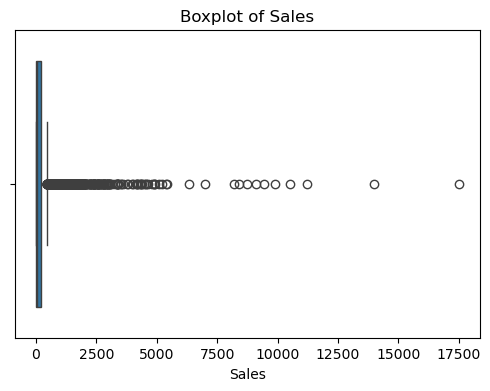

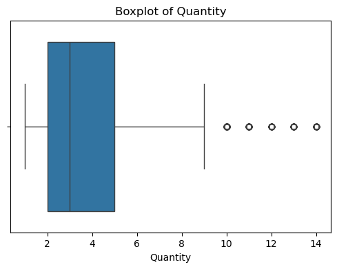

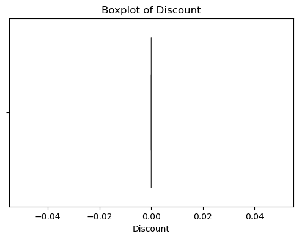

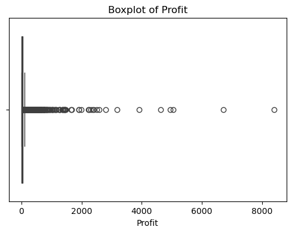

```python
import matplotlib.pyplot as plt
import seaborn as sns

# Plotting Numerical Summaries
num_cols = ['Sales', 'Quantity', 'Discount', 'Profit']

for col in num_cols:
    plt.figure(figsize=(6, 4))
    sns.boxplot(x=df[col])
    plt.title(f'Boxplot of {col}')
    plt.show()
```

## 🗂️ Categorical Features Overview

Categorical variables provide segmentation views of the data, such as:

- **Customer Segment** (Consumer, Corporate, Home Office)
- **Shipping Mode**
- **Product Category**
- **Geographic Region**

Understanding category distribution reveals where most transactions originate and which segments dominate.

```python
# Value counts for top categorical features
df[['Ship Mode', 'Segment', 'Country', 'City', 'State', 'Region', 'Category', 'Sub-Category']].describe(include='object')
```

|  | Ship Mode | Segment | Country | City | State | Region | Category | Sub-Category |
| --- | --- | --- | --- | --- | --- | --- | --- | --- |
| count | 7964 | 7964 | 7964 | 7964 | 7964 | 7964 | 7964 | 7964 |
| unique | 4 | 3 | 1 | 512 | 49 | 4 | 3 | 17 |
| top | Standard Class | Consumer | United States | New York City | California | West | Office Supplies | Paper |
| freq | 4692 | 4097 | 7964 | 864 | 1872 | 2837 | 5027 | 1370 |

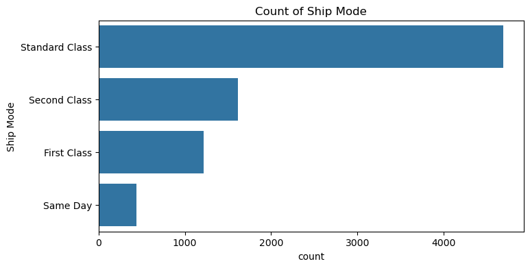

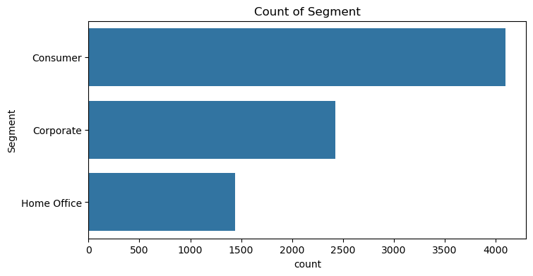

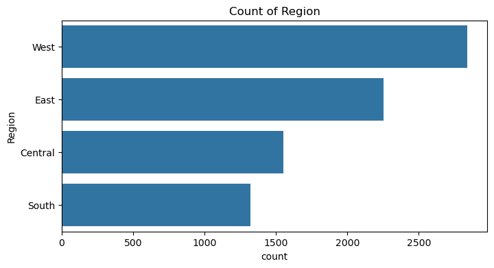

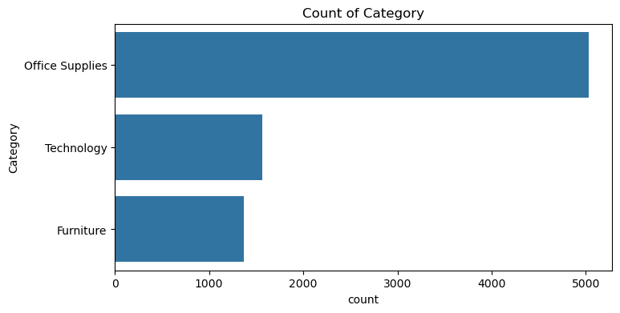

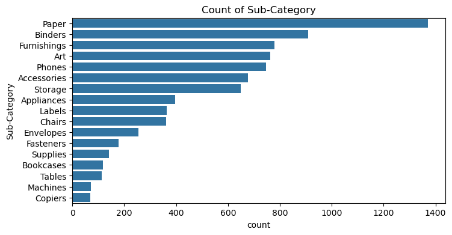

```python
cat_cols = ['Ship Mode', 'Segment', 'Region', 'Category', 'Sub-Category']

# Plotting Categorical Distributions
for col in cat_cols:
    plt.figure(figsize=(8, 4))
    sns.countplot(data=df, y=col, order=df[col].value_counts().index)
    plt.title(f'Count of {col}')
    plt.show()
```

## 🔎 Observations

- **Consumer** segment dominates sales volume.
- Most orders are shipped via **Standard Class**.
- **Office Supplies** is the most frequent product category.
- **West** region has the highest transaction volume.

## 📌 Recommendations

- While **Consumers dominate**, explore Corporate/Business segment opportunities through targeted offers.
- Audit **Standard Class** performance and costs. Explore ways to shift customers to more cost-efficient modes.
- Promote high-margin products in frequently ordered categories like **Office Supplies**.
- Use regional data to expand into less saturated markets like **Central** and **South** with focused marketing or regional pricing strategies.

📌 These observations will guide our deeper analysis into time trends, customer segmentation and product performance.

# 📅 Time-Series Analysis

Understanding how sales evolve over time helps uncover seasonal patterns, peak months, and long-term trends. This can support inventory planning, marketing campaigns, and forecasting.

### 📌 Key Questions:

- Are there seasonal sales spikes?
- Which years or months show the highest growth?
- Is the sales trend improving over time?
- What are the Monthly Average Sales?
- What are the Sales Trend for different Categories?

```python
df.set_index('Order Date', inplace=True)


monthly_sales = df['Sales'].resample('ME').sum()
monthly_discount = df['Discount'].resample('ME').sum()
monthly_profit = df['Profit'].resample('ME').sum()
monthly_quantity = df['Quantity'].resample('ME').sum()
```

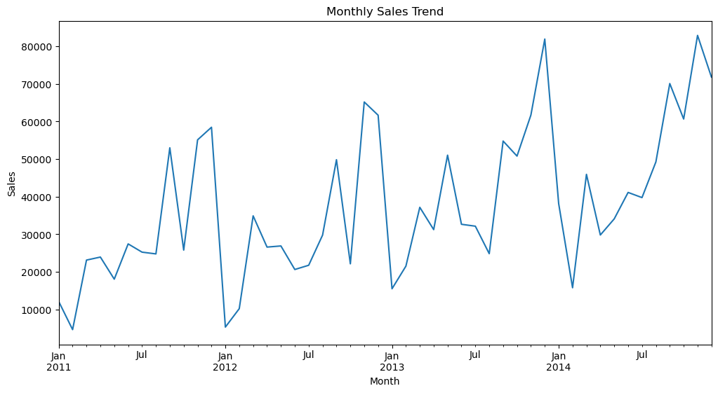

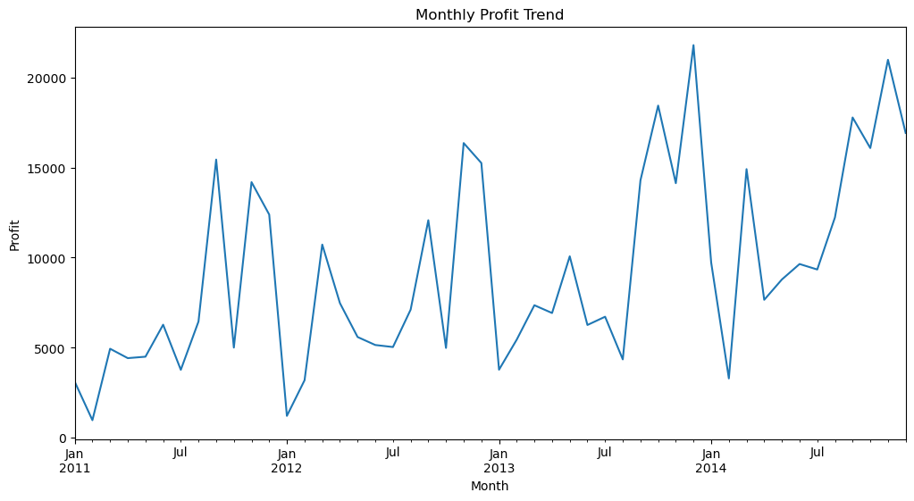

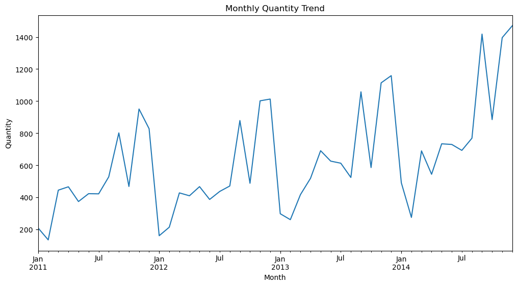

```python
plt.figure(figsize=(12, 6))
monthly_sales.plot()
plt.title('Monthly Sales Trend')
plt.xlabel('Month')
plt.ylabel('Sales')
plt.show()

plt.figure(figsize=(12, 6))
monthly_profit.plot()
plt.title('Monthly Profit Trend')
plt.xlabel('Month')
plt.ylabel('Profit')
plt.show()

plt.figure(figsize=(12, 6))
monthly_quantity.plot()
plt.title('Monthly Quantity Trend')
plt.xlabel('Month')
plt.ylabel('Quantity')
plt.show()
```

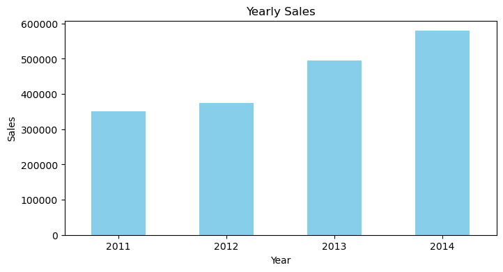

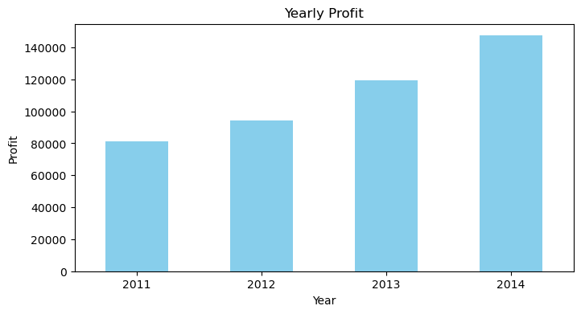

```python
df['Year'] = df.index.year
yearly_sales = df.groupby('Year')['Sales'].sum()

yearly_sales.plot(kind='bar', figsize=(8, 4), color='skyblue')
plt.title('Yearly Sales')
plt.ylabel('Sales')
plt.xticks(rotation=0)
plt.show()

df['Year'] = df.index.year
yearly_profit = df.groupby('Year')['Profit'].sum()

yearly_profit.plot(kind='bar', figsize=(8, 4), color='skyblue')
plt.title('Yearly Profit')
plt.ylabel('Profit')
plt.xticks(rotation=0)
plt.show()
```

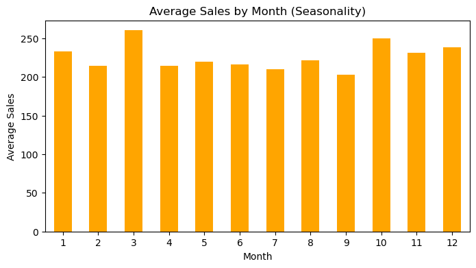

```python
df['Month'] = df.index.month
monthly_avg_sales = df.groupby('Month')['Sales'].mean()

monthly_avg_sales.plot(kind='bar', figsize=(8, 4), color='orange')
plt.title('Average Sales by Month (Seasonality)')
plt.xlabel('Month')
plt.ylabel('Average Sales')
plt.xticks(rotation=0)
plt.show()
```

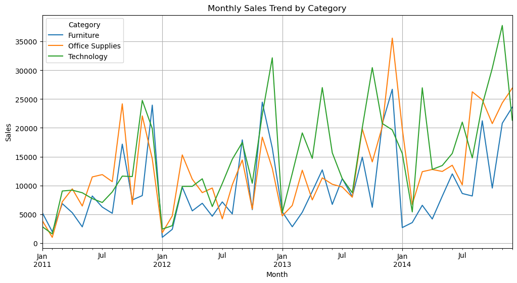

```python
category_sales = df.groupby([df.index.to_period('M'), 'Category'])['Sales'].sum().unstack()

category_sales.plot(figsize=(12, 6))
plt.title('Monthly Sales Trend by Category')
plt.ylabel('Sales')
plt.xlabel('Month')
plt.legend(title='Category')
plt.grid(True)
plt.show()
```

## 📌 Recommendations

- **Increase marketing** spend in **Q3** to capitalize on predictable Q4 spikes.
- Consider adding **campaigns** or **discounts** in slower months to lift the baseline.
- Prioritize **inventory and marketing focus on Technology** during Q4.
- **Monitor Office Supplies trends** for school/business seasonality to time promotions better.

# 👥 Customer Segmentation Analysis

## ✅ Summary

Customer segmentation helps identify patterns in purchasing behavior across different customer groups. The dataset categorizes customers into three key segments:

- **Consumer**
- **Corporate**
- **Home Office**

Analyzing their transaction volume and revenue contributions allows us to tailor business strategies for marketing, pricing, and retention.

```python
customer_df = df.groupby(['Customer ID', 'Customer Name']).agg({
    'Sales': 'sum',
    'Profit': 'sum',
    'Quantity': 'sum',
    'Segment': 'first'  # assumes one segment per customer
}).reset_index()

customer_df['Profit Margin %'] = (customer_df['Profit'] / customer_df['Sales']) * 100
```

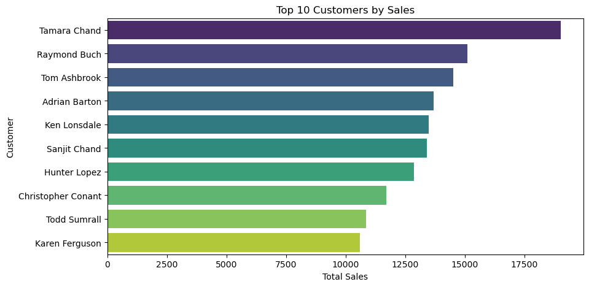

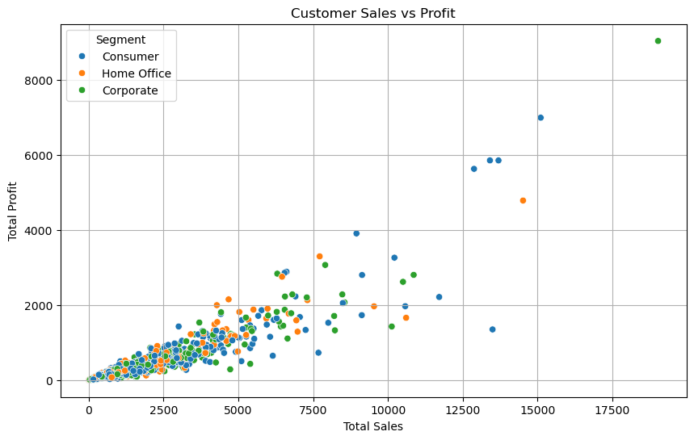

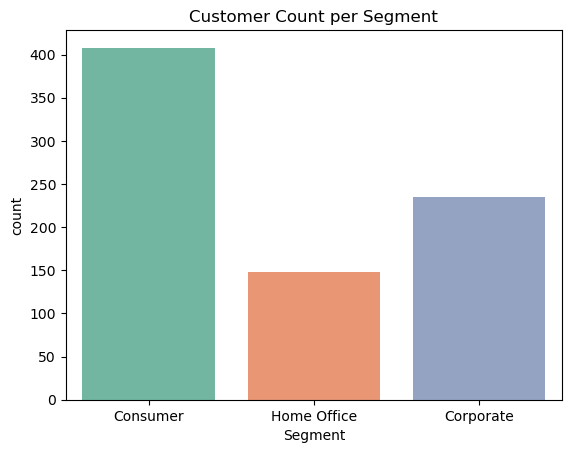

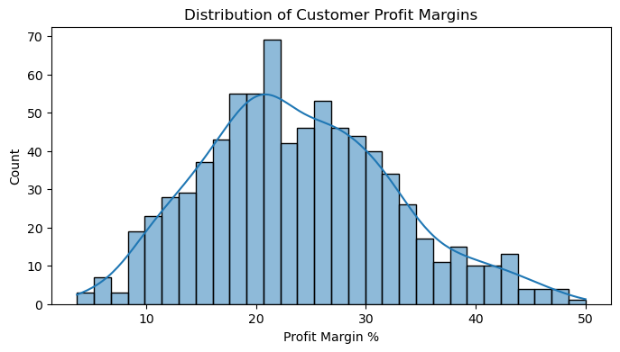

```python
top_customers = customer_df.sort_values('Sales', ascending=False).head(10)

plt.figure(figsize=(10, 5))
sns.barplot(data=top_customers, x='Sales', y='Customer Name', palette='viridis')
plt.title('Top 10 Customers by Sales')
plt.xlabel('Total Sales')
plt.ylabel('Customer')
plt.show()



plt.figure(figsize=(10, 6))
sns.scatterplot(data=customer_df, x='Sales', y='Profit', hue='Segment')
plt.title('Customer Sales vs Profit')
plt.xlabel('Total Sales')
plt.ylabel('Total Profit')
plt.grid(True)
plt.show()



sns.countplot(data=customer_df, x='Segment', palette='Set2')
plt.title('Customer Count per Segment')
plt.show()

plt.figure(figsize=(8, 4))
sns.histplot(customer_df['Profit Margin %'], kde=True, bins=30)
plt.title('Distribution of Customer Profit Margins')
plt.xlabel('Profit Margin %')
plt.show()
```

## 🔍 Key Insights

- The **Consumer segment** contributes the **highest number of orders and sales**, indicating it’s the primary revenue driver.
- **Corporate** and **Home Office** segments have **lower volume** but may represent **higher-value transactions** per order.
- Revenue per order may differ across segments — worth deeper profitability analysis.
- The segment mix may vary across regions or product categories, offering room for personalization.

## 📌 Recommendations

1. **Consumer Loyalty Programs**: Introduce a reward or referral system to maintain dominance in this segment.
2. **Corporate Upselling**: Bundle offers and enterprise packages can unlock greater value from corporate clients.
3. **Nurture Home Office Segment**: Target this underutilized group with flexible pricing or starter kits for small businesses.
4. **Segmented Marketing Campaigns**: Run personalized marketing (e.g., email campaigns) by segment to improve engagement and retention.

# 📦 Product Performance Analysis

## ✅ Summary

Analyzing product performance helps uncover which items drive revenue and which may hurt overall profitability. This includes examining product-level trends across:

- 📁 Categories (Furniture, Office Supplies, Technology)
- 🧩 Sub-Categories (e.g., Chairs, Binders, Phones)
- 🏷️ Individual products (using Product Name & ID)

Both **sales volume** and **profit contribution** are analyzed to guide inventory, marketing, and pricing decisions.

```python
product_df = df.groupby(['Product ID', 'Product Name', 'Category', 'Sub-Category']).agg({
    'Sales': 'sum',
    'Quantity': 'sum',
    'Profit': 'sum',
}).reset_index()

product_df['Profit Margin %'] = (product_df['Profit'] / product_df['Sales']) * 100
```

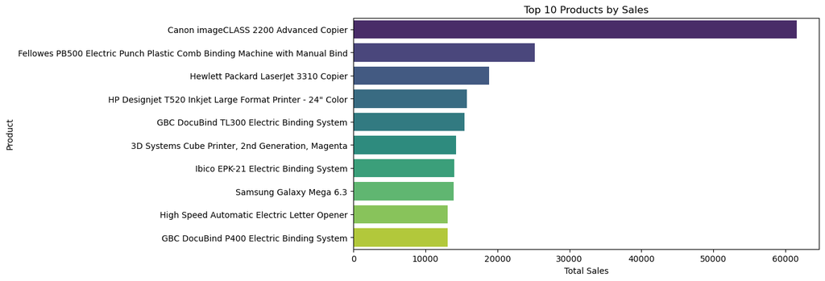

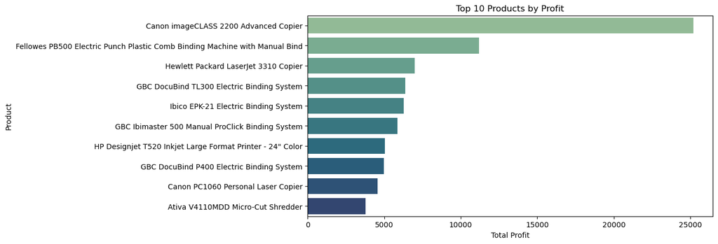

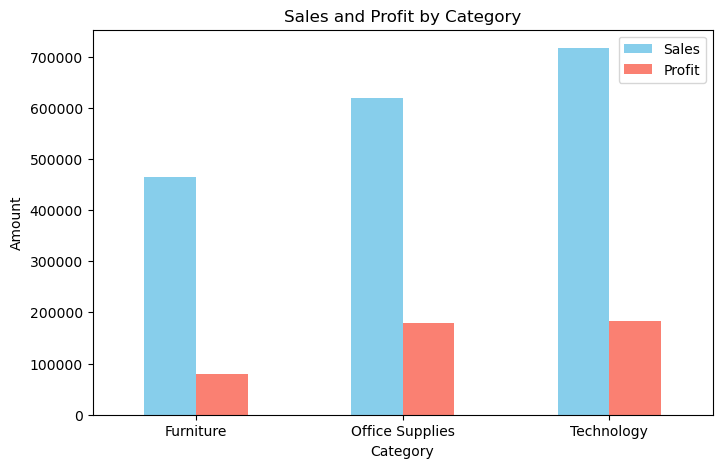

```python
top_sales = product_df.sort_values('Sales', ascending=False).head(10)

plt.figure(figsize=(10, 5))
sns.barplot(data=top_sales, y='Product Name', x='Sales', palette='viridis')
plt.title('Top 10 Products by Sales')
plt.xlabel('Total Sales')
plt.ylabel('Product')
plt.show()




top_profit = product_df.sort_values('Profit', ascending=False).head(10)

plt.figure(figsize=(10, 5))
sns.barplot(data=top_profit, y='Product Name', x='Profit', palette='crest')
plt.title('Top 10 Products by Profit')
plt.xlabel('Total Profit')
plt.ylabel('Product')
plt.show()



category_perf = df.groupby('Category')[['Sales', 'Profit']].sum().reset_index()

category_perf.plot(kind='bar', x='Category', figsize=(8, 5), color=['skyblue', 'salmon'])
plt.title('Sales and Profit by Category')
plt.ylabel('Amount')
plt.xticks(rotation=0)
plt.show()
```